# Chapter 2: Regression and model validation

In this exercise I analyze preprocessed data.

### Link to preprocessing R script:

https://github.com/neabister/IODS-project/blob/master/data/create_learning2014.R

### Link to original data:

http://www.helsinki.fi/~kvehkala/JYTmooc/JYTOPKYS3-data.txt

### Original data and preprocessing

Data is from Introduction to statistics course learning approaches study carried out in Helsinki 2014 and it is a part of multinational study. Approaches are defined by ASSIST guidelines and divided into three categories: Deep, Surface and Strategic study approaches. Students participated by filling in questionaires relating to these 3 approaches by answering 1-5 (least agreeing - most agreeing). In addition, data contains a measure for each student’s attitude and achievements based on exam points.

In preprocessing, questions were divided into **Deep, Surface** and **Strategic** groups and for each group mean was calculated for each student. Analysis dataset includes additional information on gender, attitude and exam points. Students who had 0 points from exam were excluded.

### Data analysis

#### Read the data and explore it

```r
data <- read.csv('data/analysis_dataset.csv')
head(data)
```

```
##   gender age attitude points     deep  stra     surf
## 1      F  53      3.7     25 3.583333 3.375 2.583333
## 2      M  55      3.1     12 2.916667 2.750 3.166667
## 3      F  49      2.5     24 3.500000 3.625 2.250000
## 4      M  53      3.5     10 3.500000 3.125 2.250000
## 5      M  49      3.7     22 3.666667 3.625 2.833333
## 6      F  38      3.8     21 4.750000 3.625 2.416667
```

```r
dim(data)
```

```
## [1] 166   7
```

```r
str(data)
```

```
## 'data.frame':    166 obs. of  7 variables:
##  $ gender  : Factor w/ 2 levels "F","M": 1 2 1 2 2 1 2 1 2 1 ...
##  $ age     : int  53 55 49 53 49 38 50 37 37 42 ...
##  $ attitude: num  3.7 3.1 2.5 3.5 3.7 3.8 3.5 2.9 3.8 2.1 ...
##  $ points  : int  25 12 24 10 22 21 21 31 24 26 ...
##  $ deep    : num  3.58 2.92 3.5 3.5 3.67 ...
##  $ stra    : num  3.38 2.75 3.62 3.12 3.62 ...
##  $ surf    : num  2.58 3.17 2.25 2.25 2.83 ...
```

*Data contains 7 variables (columns) from 166 observations (students, rows). All variables are numeric or integers except gender which has 2 factors (female or male).*

### Summary and graphical overview of the data

```r
summary(data)
```

```
##  gender       age           attitude         points           deep
##  F:110   Min.   :17.00   Min.   :1.400   Min.   : 7.00   Min.   :1.583
##  M: 56   1st Qu.:21.00   1st Qu.:2.600   1st Qu.:19.00   1st Qu.:3.333
##          Median :22.00   Median :3.200   Median :23.00   Median :3.667
##          Mean   :25.51   Mean   :3.143   Mean   :22.72   Mean   :3.680
##          3rd Qu.:27.00   3rd Qu.:3.700   3rd Qu.:27.75   3rd Qu.:4.083
##          Max.   :55.00   Max.   :5.000   Max.   :33.00   Max.   :4.917
##       stra            surf
##  Min.   :1.250   Min.   :1.583
##  1st Qu.:2.625   1st Qu.:2.417
##  Median :3.188   Median :2.833
##  Mean   :3.121   Mean   :2.787
##  3rd Qu.:3.625   3rd Qu.:3.167
##  Max.   :5.000   Max.   :4.333
```

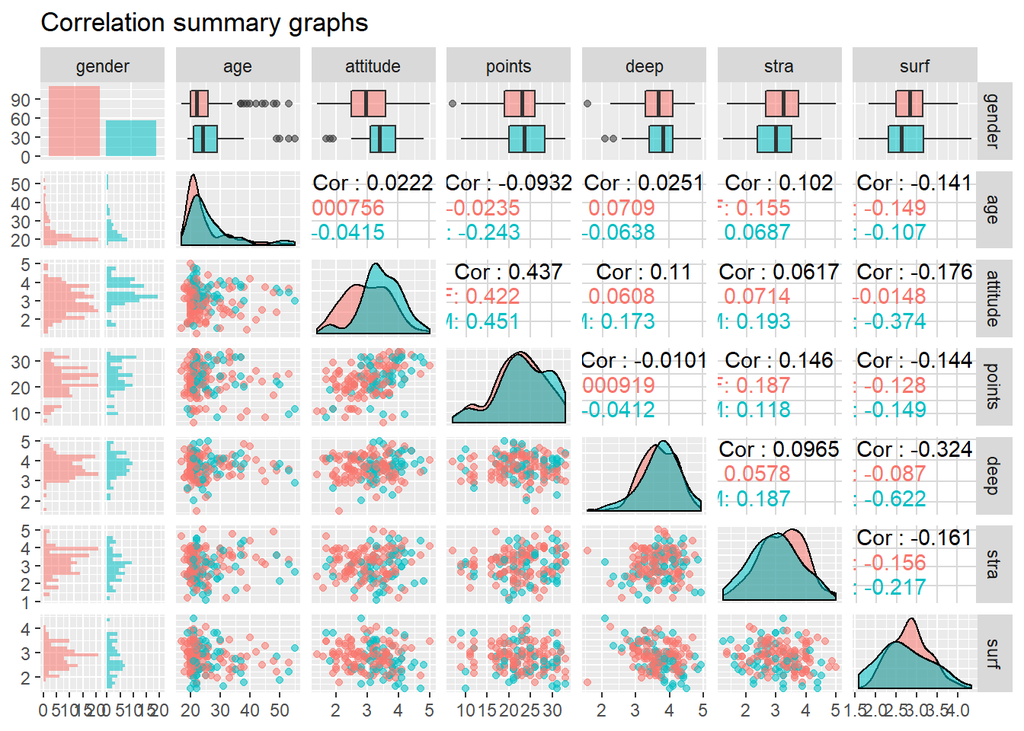

```r
library(ggplot2)
library(GGally)
p <- ggpairs(data, title = "Correlation summary graphs", mapping = aes(col = gender, alpha = 0.4), lower = list(combo = wrap('facethist', bins = 20)))

p
```

### Linear regression fitting

To try to explain target variable **points**, I selected 3 variables that had highest negative or positive correlation (**attitude**, **stra**, **surf**) with it and fitted linear regression.

```r
linear_3_variables <- lm(points ~ attitude + stra + surf, data = data)
summary(linear_3_variables)
```

```
##
## Call:
## lm(formula = points ~ attitude + stra + surf, data = data)
##
## Residuals:
##      Min       1Q   Median       3Q      Max
## -17.1550  -3.4346   0.5156   3.6401  10.8952
##
## Coefficients:
##             Estimate Std. Error t value Pr(>|t|)
## (Intercept)  11.0171     3.6837   2.991  0.00322 **
## attitude      3.3952     0.5741   5.913 1.93e-08 ***
## stra          0.8531     0.5416   1.575  0.11716
## surf         -0.5861     0.8014  -0.731  0.46563
## ---
## Signif. codes:  0 '***' 0.001 '**' 0.01 '*' 0.05 '.' 0.1 ' ' 1
##
## Residual standard error: 5.296 on 162 degrees of freedom
## Multiple R-squared:  0.2074, Adjusted R-squared:  0.1927
## F-statistic: 14.13 on 3 and 162 DF,  p-value: 3.156e-08
```

*Attitude is the only significant variable to explain points.*

### Fitting linear regression using only significant **attitude** variable

```r
linear_attitude <- lm(points ~ attitude, data = data)
summary(linear_attitude)
```

```
##
## Call:
## lm(formula = points ~ attitude, data = data)
##
## Residuals:
##      Min       1Q   Median       3Q      Max
## -16.9763  -3.2119   0.4339   4.1534  10.6645
##
## Coefficients:
##             Estimate Std. Error t value Pr(>|t|)
## (Intercept)  11.6372     1.8303   6.358 1.95e-09 ***
## attitude      3.5255     0.5674   6.214 4.12e-09 ***
## ---
## Signif. codes:  0 '***' 0.001 '**' 0.01 '*' 0.05 '.' 0.1 ' ' 1
##
## Residual standard error: 5.32 on 164 degrees of freedom
## Multiple R-squared:  0.1906, Adjusted R-squared:  0.1856
## F-statistic: 38.61 on 1 and 164 DF,  p-value: 4.119e-09
```

*By removing non-significant variables, Adj. R<sup>2</sup> is marginally reducing, meaning that slightly less of the variance in **points** is explained by **attitude**. However, F-statistic p-value is also decreasing in a model with attitude variable alone, suggesting that the fit of a single regression model would be better for the data. Both of the models give relatively high residual std errors when compared to 1st and 3rd residual quantiles*

### Diagnostic plots for single regression

`Residuals vs Fitted values`, `Normal QQ-plot and` and `Residuals vs Leverage` diagnostic plots produced.

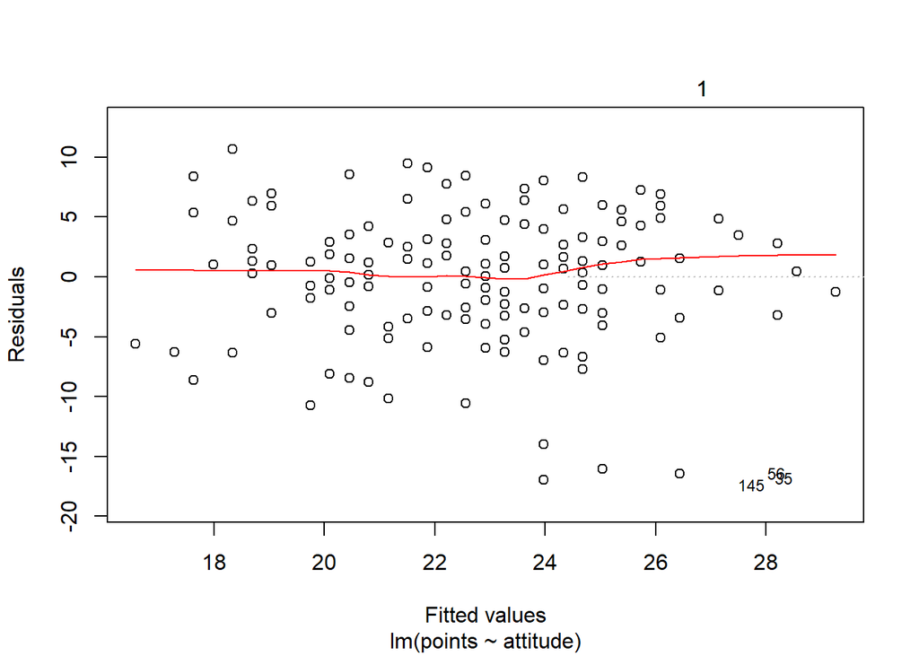

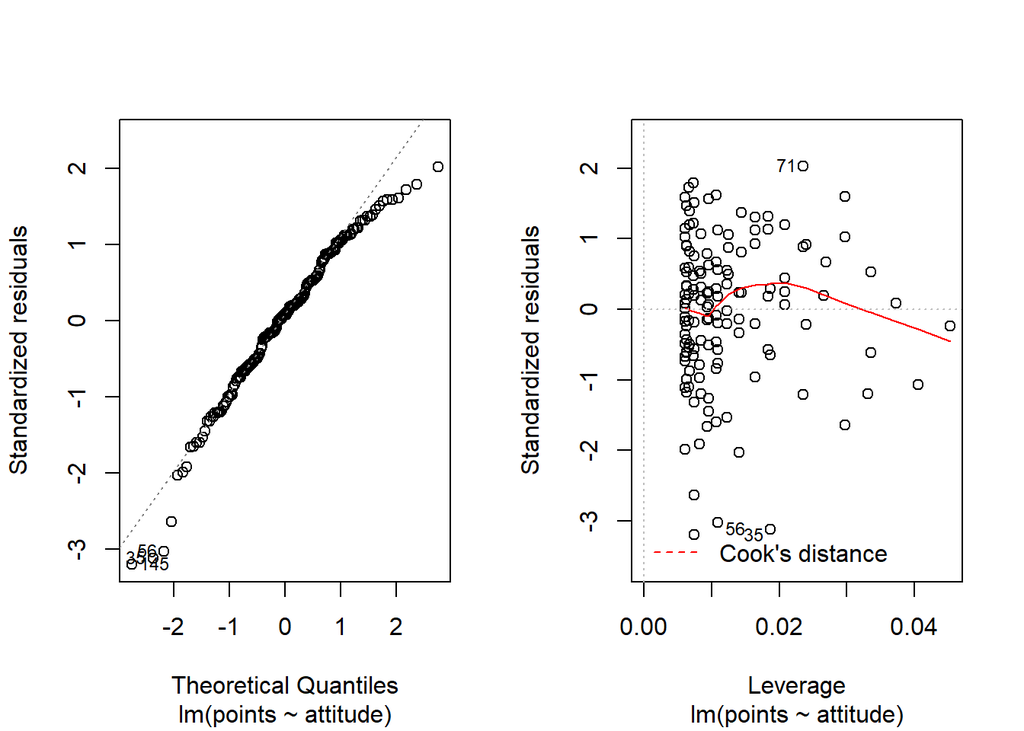

```r
plot_diagnostics2 <- plot(linear_attitude, which = c(1, 2, 5), par(mfrow = c(1,2)))
```

**Residuals vs. Fitted values**: Reasonable constant variation of residual errors, graph should not show any patterns.  
**QQ-plot:** Normality of errors is reasonable  
**Leverage:** Indicates the impact of individual points on the fitted model. My model has reasonable leverage.

### Testing stepwise multiple regression

I realized it would be slow to observe manually all possible variable combinations, so I looked for an automated one to ensure I find the best model. Here I test `ols_step_both_p` function from `olsrr package`. It is selecting variables to the model based on their p values and the thresholds to include or exclude a variable can be manually adjusted (more information here https://www.guru99.com/r-simple-multiple-linear-regression.html.

```r
library(olsrr)
fit <- lm(points ~ factor(gender) + age + attitude + deep + stra + surf, data = data)
best <- ols_step_both_p(fit)
```

```
## Stepwise Selection Method
## ---------------------------
##
## Candidate Terms:
##
## 1. factor(gender)
## 2. age
## 3. attitude
## 4. deep
## 5. stra
## 6. surf
##
## We are selecting variables based on p value...
##
## Variables Entered/Removed:
##
## - attitude added
## - stra added
## - age added
##
## No more variables to be added/removed.
##
##
## Final Model Output
## ------------------
##
##                         Model Summary
## --------------------------------------------------------------
## R                       0.467       RMSE                5.260
## R-Squared               0.218       Coef. Var          23.156
## Adj. R-Squared          0.204       MSE                27.671
## Pred R-Squared          0.176       MAE                 4.120
## --------------------------------------------------------------
##  RMSE: Root Mean Square Error
##  MSE: Mean Square Error
##  MAE: Mean Absolute Error
##
##                                 ANOVA
## ---------------------------------------------------------------------
##                 Sum of
##                Squares         DF    Mean Square      F         Sig.
## ---------------------------------------------------------------------
## Regression    1250.931          3        416.977    15.069    0.0000
## Residual      4482.762        162         27.671
## Total         5733.693        165
## ---------------------------------------------------------------------
##
##                                   Parameter Estimates
## ----------------------------------------------------------------------------------------
##       model      Beta    Std. Error    Std. Beta      t        Sig      lower     upper
## ----------------------------------------------------------------------------------------
## (Intercept)    10.895         2.648                  4.114    0.000     5.666    16.125
##    attitude     3.481         0.562        0.431     6.191    0.000     2.371     4.591
##        stra     1.004         0.534        0.131     1.878    0.062    -0.051     2.059
##         age    -0.088         0.053       -0.116    -1.664    0.098    -0.193     0.016
## ----------------------------------------------------------------------------------------
```

```r
best
```

```
##
##                              Stepwise Selection Summary
## -------------------------------------------------------------------------------------
##                      Added/                   Adj.
## Step    Variable    Removed     R-Square    R-Square     C(p)        AIC        RMSE
## -------------------------------------------------------------------------------------
##    1    attitude    addition       0.191       0.186    5.3960    1029.9875    5.3197
##    2      stra      addition       0.205       0.195    4.4470    1029.0379    5.2888
##    3      age       addition       0.218       0.204    3.6840    1028.2247    5.2604
## -------------------------------------------------------------------------------------
```

### Best fit diagnostic plots

```r
best_fit <- lm(points ~ attitude + stra + age, data = data)
summary(best_fit)
```

```
##
## Call:
## lm(formula = points ~ attitude + stra + age, data = data)
##
## Residuals:
##      Min       1Q   Median       3Q      Max
## -18.1149  -3.2003   0.3303   3.4129  10.7599
##
## Coefficients:
##             Estimate Std. Error t value Pr(>|t|)
## (Intercept) 10.89543    2.64834   4.114 6.17e-05 ***
## attitude     3.48077    0.56220   6.191 4.72e-09 ***
## stra         1.00371    0.53434   1.878   0.0621 .
## age         -0.08822    0.05302  -1.664   0.0981 .
## ---
## Signif. codes:  0 '***' 0.001 '**' 0.01 '*' 0.05 '.' 0.1 ' ' 1
##
## Residual standard error: 5.26 on 162 degrees of freedom
## Multiple R-squared:  0.2182, Adjusted R-squared:  0.2037
## F-statistic: 15.07 on 3 and 162 DF,  p-value: 1.07e-08
```

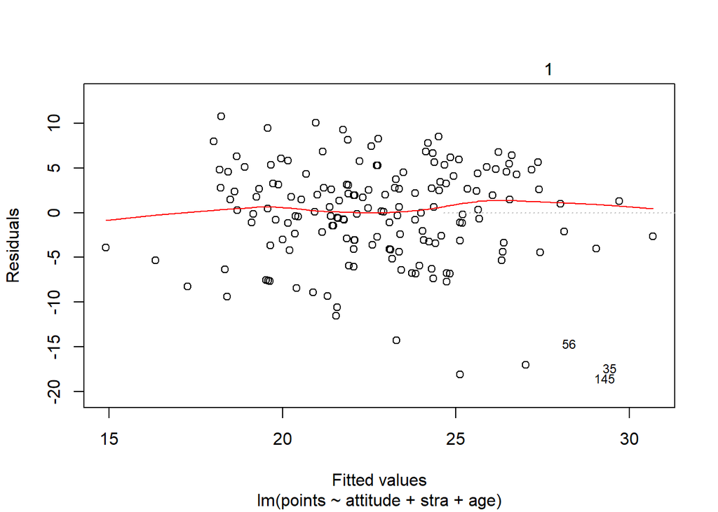

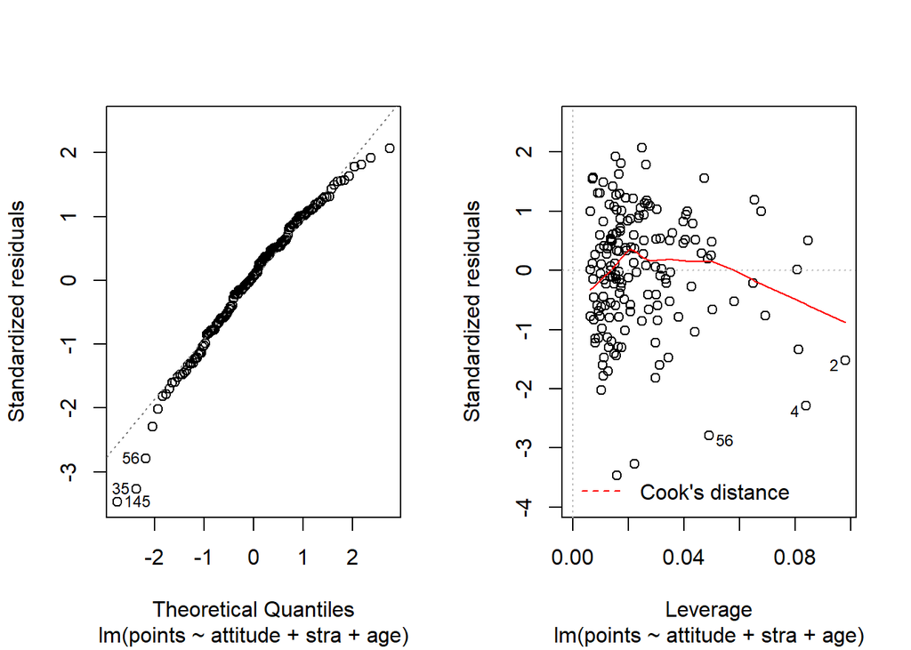

```r
best_fit_diagn <- plot(best_fit, which = c(1, 2, 5), par(mfrow = c(1,2)))
```

### Conclusions

Overall power of the fitted models to explain points variablity is limited. Adjusted R<sup>2</sup> is quite low for all explored models and residual errors remain quite high. Based on F-statistics p-value, and observation that attitude was the only significant variable associated with points, single regression model could be sufficient model to use for rougly estimate student’s future achievements in exams. The better the attitude of a student is, the higher exam points they are likely to have which makes sense.  
However, `olsrr` library function pinpointed a multiple regression model (**attitude**, **stra** and **age**) that explains points variation even better. Rough interpretation of this model:  
1. Higher attitude -> Higher points (positive correlation)  
2. Higher strategic approach -> Higher points (positive correlation)  
3. Older age -> Lower points (negative correlation)  
4. Impact of these three variables on points is: attitude > stra > age